# Massachusetts pediatric influenza hospitalizations: counterfactual analysis

## Summary

This analysis estimates excess influenza hospitalizations among Massachusetts children (6 months–17 years) under a scenario of reduced vaccine coverage.

| Metric | Value |
| --- | --- |
| Observed pediatric flu hospitalizations (MA, 2024–25 season) | 617 |
| Baseline vaccine coverage (FluVaxView 2023–24) | 75.1% (95% CI: 72.3–77.9); 0.75 for modeling |
| Scenario modeled | 50% drop: coverage falls 0.75 → 0.375 |
| Vaccine effectiveness (VE) range | 0.35–0.60 |

**Estimated excess hospitalizations under the 50% relative drop scenario:**

[output not shown]

*90% uncertainty interval = 5th to 95th percentile of Monte Carlo draws.*

## Data sources

- **NHSN Hospital Respiratory Data (HRD)**: Weekly pediatric confirmed influenza new admissions for Massachusetts. Source: CDC Data Portal, Socrata dataset `ua7e-t2fy`. The hospitalization field used is `totalconfflunewadmped` (total confirmed flu new admissions, pediatric).
- **CDC FluVaxView**: Seasonal influenza vaccination coverage for Massachusetts children ages 6 months–17 years. Source: CDC Data Portal, Socrata dataset `vh55-3he6`.

*Hospitalizations are pediatric (ages 0–17) while coverage is vaccine-eligible (6 months–17 years); results are interpreted for the vaccine-eligible group.*

## Model

We model vaccination as a **partially effective vaccine** that reduces the risk of hospitalization by a fixed fraction (vaccine effectiveness, VE) for each vaccinated child.

**Put plainly:** We back-calculate the hospitalization burden that would have occurred with no vaccination, then re-apply a lower coverage level to estimate the flu burden under reduced vaccine uptake.

**Definitions:**

- $B_{obs}$: observed hospitalizations in the season
- $c_0$: baseline coverage (fraction vaccinated)
- $c_1$: counterfactual coverage (fraction vaccinated under a lower-uptake scenario)
- $VE$: vaccine effectiveness (fractional reduction in hospitalization risk for vaccinated children)

**Equations:**

$$B_0 = \frac{B_{obs}}{1 - c_0 \cdot
VE}$$
$$B_1 = B_0 \cdot (1 - c_1 \cdot
VE)$$
$$\Delta B = B_1 -
B_{obs}$$

Where $B_0$ is the implied burden with no vaccination and $\Delta B$ is the excess burden under reduced coverage.

**Some assumptions and notes:**

- VE applies to hospitalization risk (not infection risk alone)
- VE is constant across the season (no waning)
- No explicit transmission model; herd effects are addressed separately via a multiplier from the literature
- Pediatric influenza hospitalizations for Massachusetts are only available in NHSN starting in 2024–25.
- Vaccine uptake/coverage uses the most recent published FluVaxView value (2023–24 season)
- Hospitalizations cover ages 0–17
- Vaccine uptake/coverage data is for ages 6 months–17 years

```r
library(httr)
library(jsonlite)
library(dplyr)
library(tidyr)
library(ggplot2)
library(scales)
library(knitr)
library(kableExtra)

# Create output directory
output_dir <- "outputs"
if (!dir.exists(output_dir)) dir.create(output_dir)
```

## Parameters and Helper

```r
season_id <- "2024-25"
season_start <- "2024-10-01"
season_end <- "2025-04-30"

hrd_domain <- "data.cdc.gov"
hrd_dataset <- "ua7e-t2fy"
hrd_week_col <- "weekendingdate"
hrd_jurisdiction_col <- "jurisdiction"
hrd_jurisdiction_value <- "MA"
hrd_hosp_col <- "totalconfflunewadmped"

coverage_domain <- "data.cdc.gov"
coverage_dataset <- "vh55-3he6"
coverage_season_override <- "2023-24"
coverage_baseline <- 0.75

ve_grid <- seq(0.35, 0.60, by = 0.05)
coverage_grid <- seq(0.75, 0.00, by = -0.05)

socrata_get <- function(domain, dataset_id, params, limit = 50000) {
  records <- list()
  offset <- 0

  repeat {
    params[["$limit"]] <- limit
    params[["$offset"]] <- offset

    url <- sprintf("https://%s/resource/%s.json", domain, dataset_id)
    resp <- GET(url, query = params)
    stop_for_status(resp)

    data <- content(resp, as = "parsed", simplifyVector = TRUE)

    if (length(data) == 0) break

    records <- c(records, list(data))

    if (nrow(data) < limit) break
    offset <- offset + limit
  }

  bind_rows(records)
}
```

## Observed hospitalizations

```r
where_clause <- sprintf(
  "%s = '%s' AND %s between '%s' and '%s'",
  hrd_jurisdiction_col, hrd_jurisdiction_value,
  hrd_week_col, season_start, season_end
)

params <- list(
  `$select` = paste(hrd_week_col, hrd_hosp_col, sep = ","),
  `$where` = where_clause,
  `$order` = hrd_week_col
)

df_weekly <- socrata_get(hrd_domain, hrd_dataset, params)

df_weekly <- df_weekly %>%
  mutate(
    !!hrd_week_col := as.Date(!!sym(hrd_week_col)),
    !!hrd_hosp_col := as.numeric(!!sym(hrd_hosp_col))
  ) %>%
  mutate(!!hrd_hosp_col := replace_na(!!sym(hrd_hosp_col), 0))

B_obs <- sum(df_weekly[[hrd_hosp_col]], na.rm = TRUE)
n_weeks <- nrow(df_weekly)
```

**Observed total:** 617 pediatric flu hospitalizations over 30 weeks.

## Baseline coverage

```r
coverage_where <- sprintf(
  "geography='Massachusetts' AND dimension='6 Months - 17 Years' AND dimension_type='Age' AND geography_type='States/Local Areas' AND vaccine='Seasonal Influenza' AND month='5' AND year_season='%s'",
  coverage_season_override
)

coverage_params <- list(
  `$select` = "year_season,coverage_estimate,_95_ci",
  `$where` = coverage_where
)

df_cov <- socrata_get(coverage_domain, coverage_dataset, coverage_params)
```

```r
if (nrow(df_cov) > 0) {
  coverage_estimate <- as.numeric(df_cov$coverage_estimate[1]) / 100
  coverage_ci <- df_cov$`_95_ci`[1]
} else {
  coverage_estimate <- NA
  coverage_ci <- NA
}
```

**FluVaxView estimate (2023–24):** 75.1% (95% CI: 72.3 to 77.9).

## Counterfactual grid

For each combination of VE and coverage, we compute the implied no-vaccination burden and the counterfactual burden under lower coverage. Excess hospitalizations are the difference from observed.

```r
df_results <- expand.grid(VE = ve_grid, c1 = coverage_grid) %>%
  mutate(
    season_id = season_id,
    B_obs = B_obs,
    c0 = coverage_baseline,
    denom = 1 - c0 * VE
  ) %>%
  filter(denom > 0) %>%
  mutate(
    B0 = B_obs / denom,
    B1_point = B0 * (1 - c1 * VE),
    excess_point = B1_point - B_obs
  ) %>%
  select(season_id, B_obs, c0, c1, VE, B1_point, excess_point)

output_path <- file.path(output_dir, sprintf("ma_under17_flu_counterfactual_%s.csv", season_id))
write.csv(df_results, output_path, row.names = FALSE)
cat(sprintf("Saved to: %s\n", output_path))
```

```
## Saved to: outputs/ma_under17_flu_counterfactual_2024-25.csv
```

## Basic excess model

The heatmap summarizes excess hospitalizations across the VE and coverage grid. Lighter colors indicate lower excess burden; darker reds indicate higher excess burden.

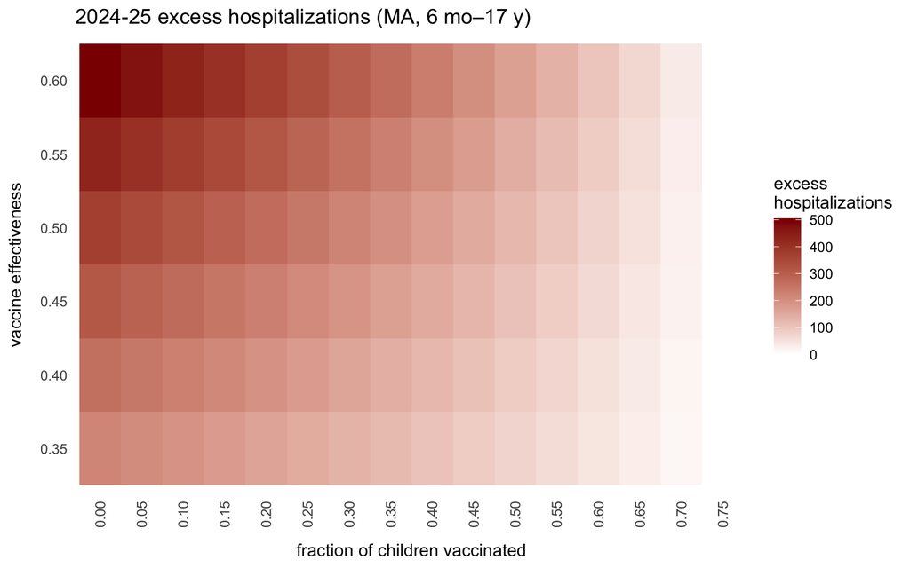

```r
ggplot(df_results, aes(x = factor(c1), y = factor(VE), fill = excess_point)) +
  geom_tile() +
  scale_fill_gradient(low = "white", high = "darkred", name = "excess\nhospitalizations") +
  scale_x_discrete(labels = function(x) sprintf("%.2f", as.numeric(x))) +
  scale_y_discrete(labels = function(x) sprintf("%.2f", as.numeric(x))) +
  labs(
    title = sprintf("%s excess hospitalizations (MA, 6 mo–17 y)", season_id),
    x = "fraction of children vaccinated",
    y = "vaccine effectiveness"
  ) +
  theme_minimal() +
  theme(
    axis.text.x = element_text(angle = 90, hjust = 1, vjust = 0.5),
    axis.title.x = element_text(margin = margin(t = 10)),
    axis.title.y = element_text(margin = margin(r = 10)),
    panel.grid = element_blank(),
    axis.ticks = element_blank()
  )
```

## Herd effects extension

The basic excess model captures protection for vaccinated individuals only. To show how results might increase if reduced coverage modestly increases transmission (herd effects), we multiply the basic excess by a factor M.

We set **M = 1.2** as a modest scenario (20% additional excess), motivated by household-based analyses showing that indirect protection is limited, on the order of up to ~20% reduction in infection risk for unvaccinated household members even under optimistic assumptions about within-household transmission ([Tsang et al., 2018](https://www.nature.com/articles/s41467-018-08036-6)).

Because indirect effects are setting- and season-dependent, we also show a sensitivity band **M ∈ [1.0, 1.4]**.

```r
M_modest <- 1.2
M_low <- 1.0
M_high <- 1.4

df_results_herd <- df_results %>%
  mutate(
    excess_direct_point = excess_point,
    excess_herd_modest_point = M_modest * excess_point,
    excess_herd_low_point = M_low * excess_point,
    excess_herd_high_point = M_high * excess_point,
    B1_direct_point = B_obs + excess_direct_point,
    B1_herd_modest_point = B_obs + excess_herd_modest_point,
    B1_herd_low_point = B_obs + excess_herd_low_point,
    B1_herd_high_point = B_obs + excess_herd_high_point
  )

output_path_herd <- file.path(output_dir, sprintf("ma_under17_flu_counterfactual_%s_herd.csv", season_id))
write.csv(df_results_herd, output_path_herd, row.names = FALSE)
cat(sprintf("Saved to: %s\n", output_path_herd))
```

```
## Saved to: outputs/ma_under17_flu_counterfactual_2024-25_herd.csv
```

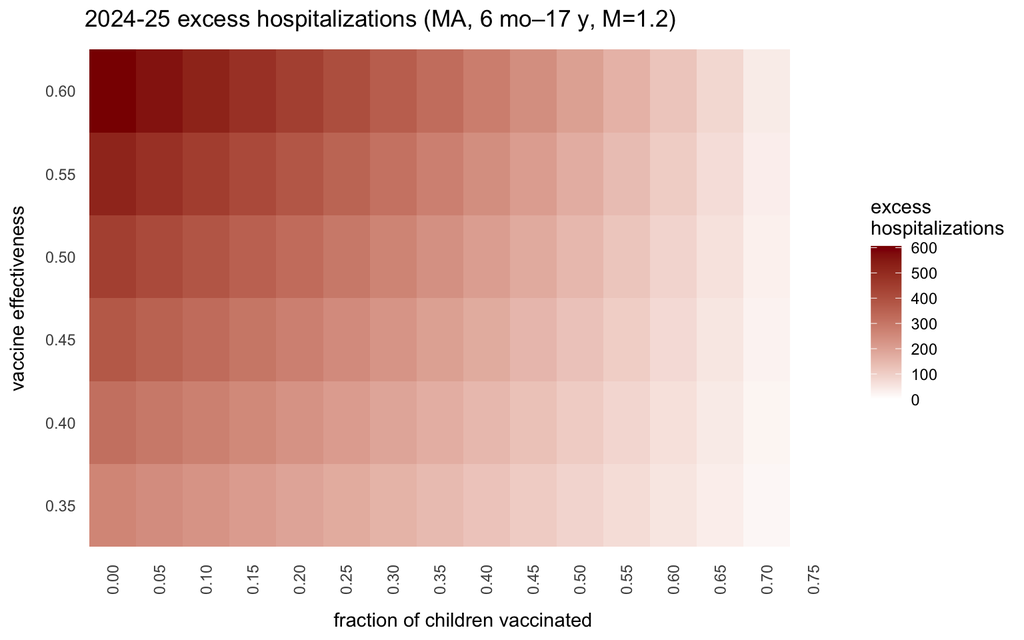

```r
ggplot(df_results_herd, aes(x = factor(c1), y = factor(VE), fill = excess_herd_modest_point)) +
  geom_tile() +
  scale_fill_gradient(low = "white", high = "darkred", name = "excess\nhospitalizations") +
  scale_x_discrete(labels = function(x) sprintf("%.2f", as.numeric(x))) +
  scale_y_discrete(labels = function(x) sprintf("%.2f", as.numeric(x))) +
  labs(
    title = sprintf("%s excess hospitalizations (MA, 6 mo–17 y, M=1.2)", season_id),
    x = "fraction of children vaccinated",
    y = "vaccine effectiveness"
  ) +
  theme_minimal() +
  theme(
    axis.text.x = element_text(angle = 90, hjust = 1, vjust = 0.5),
    axis.title.x = element_text(margin = margin(t = 10)),
    axis.title.y = element_text(margin = margin(r = 10)),
    panel.grid = element_blank(),
    axis.ticks = element_blank()
  )
```

## Uncertainty quantification

To avoid presenting a single point estimate, we use Monte Carlo simulation to propagate uncertainty.

**Uncertainty sources:**

- **Count variability:** The observed seasonal total (617) is treated as a realized value that could vary around its mean. We approximate this variability with a Poisson model.
- **VE uncertainty:** Vaccine effectiveness is drawn uniformly from the range (0.35–0.60).

For each of 20,000 Monte Carlo draws, we sample both parameters and compute the excess hospitalizations under the counterfactual scenario. Results are summarized as median and 90% uncertainty interval.

```r
set.seed(12345)

# Scenario definition: 50% relative drop means 0.75 -> 0.375
scenario_label <- "50% relative drop"
c1_scenario <- coverage_baseline * 0.5

# Uncertainty parameters
n_draws <- 20000
ve_low <- min(ve_grid)
ve_high <- max(ve_grid)

M_modest <- 1.2
M_uniform_low <- 1.0
M_uniform_high <- 1.4

# Monte Carlo simulation
B_obs_draw <- rpois(n_draws, lambda = B_obs)
VE_draw <- runif(n_draws, min = ve_low, max = ve_high)

denom <- 1 - coverage_baseline * VE_draw
ok <- denom > 1e-12

# Initialize vectors
excess_direct <- rep(NA_real_, n_draws)
excess_herd_modest <- rep(NA_real_, n_draws)
excess_herd_uniform <- rep(NA_real_, n_draws)

# Compute excess for valid draws
B0 <- B_obs_draw[ok] / denom[ok]
B1 <- B0 * (1 - c1_scenario * VE_draw[ok])
excess <- B1 - B_obs_draw[ok]

excess_direct[ok] <- excess
excess_herd_modest[ok] <- M_modest * excess

M_draw <- runif(sum(ok), min = M_uniform_low, max = M_uniform_high)
excess_herd_uniform[ok] <- M_draw * excess

# Remove NAs
excess_direct <- excess_direct[!is.na(excess_direct)]
excess_herd_modest <- excess_herd_modest[!is.na(excess_herd_modest)]
excess_herd_uniform <- excess_herd_uniform[!is.na(excess_herd_uniform)]

# Summary function
summarize_draws <- function(arr, model_name) {
  data.frame(
    Model = model_name,
    Median = round(median(arr)),
    `5th percentile` = round(unname(quantile(arr, 0.05))),
    `95th percentile` = round(unname(quantile(arr, 0.95))),
    check.names = FALSE
  )
}

df_uncertainty <- bind_rows(
  summarize_draws(excess_direct, "Direct only (M=1.0)"),
  summarize_draws(excess_herd_modest, "Direct + modest herd (M=1.2)"),
  summarize_draws(excess_herd_uniform, "Direct + herd uncertainty (M~U[1.0,1.4])")
)
```

### Results

**Scenario: 50% relative drop** (coverage drops from 0.75 to 0.375)

```r
kable(df_uncertainty,
      col.names = c("Model", "Median", "5th percentile", "95th percentile"),
      align = c("l", "r", "r", "r")) %>%
  kable_styling(
    bootstrap_options = c("striped", "hover", "condensed"),
    full_width = FALSE,
    position = "left",
    font_size = 14
  ) %>%
  column_spec(1, width = "18em") %>%
  column_spec(2, bold = TRUE, width = "6em", background = "#f0f7fa") %>%
  column_spec(3, width = "8em") %>%
  column_spec(4, width = "8em") %>%
  row_spec(0, bold = TRUE, background = "#2E86AB", color = "white") %>%
  add_header_above(c(" " = 1, "Estimated excess hospitalizations" = 3),
                   background = "#1a5f7a", color = "white", bold = TRUE) %>%
  footnote(general = "90% uncertainty interval = 5th to 95th percentile of Monte Carlo draws.",
           general_title = "Note: ",
           footnote_as_chunk = TRUE)
```

| Model | Estimated excess hospitalizations Median | Estimated excess hospitalizations 5th percentile | Estimated excess hospitalizations 95th percentile |
| --- | --- | --- | --- |
| Direct only (M=1.0) | 171 | 115 | 244 |
| Direct + modest herd (M=1.2) | 206 | 138 | 293 |
| Direct + herd uncertainty (M~U[1.0,1.4]) | 204 | 132 | 305 |

Note: 90% uncertainty interval = 5th to 95th percentile of Monte Carlo draws.

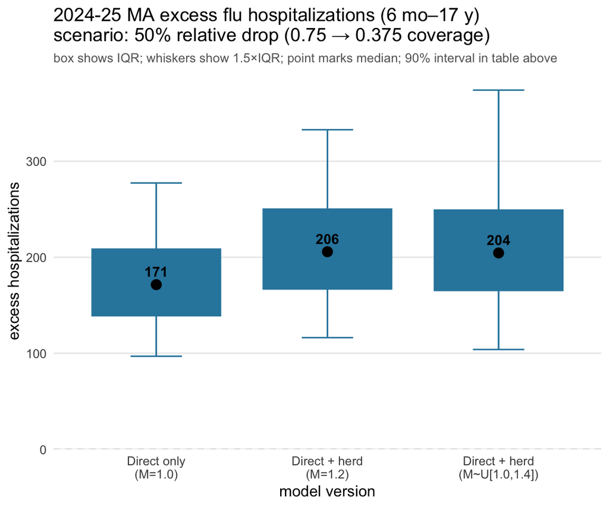

```r
# Prepare data for box plot
mc_data <- data.frame(
  model = c(
    rep("Direct only\n(M=1.0)", length(excess_direct)),
    rep("Direct + herd\n(M=1.2)", length(excess_herd_modest)),
    rep("Direct + herd\n(M~U[1.0,1.4])", length(excess_herd_uniform))
  ),
  value = c(excess_direct, excess_herd_modest, excess_herd_uniform)
)

mc_data$model <- factor(mc_data$model, levels = c(
  "Direct only\n(M=1.0)",
  "Direct + herd\n(M=1.2)",
  "Direct + herd\n(M~U[1.0,1.4])"
))

# Compute medians for labels
medians <- mc_data %>%
  group_by(model) %>%
  summarize(
    median_val = median(value),
    p05 = quantile(value, 0.05),
    p95 = quantile(value, 0.95)
  )

box_color <- "#2E86AB"

ggplot(mc_data, aes(x = model, y = value)) +
  geom_hline(yintercept = 0, linetype = "dashed", color = "gray", alpha = 0.5) +
  stat_boxplot(
    geom = "errorbar",
    width = 0.3,
    color = box_color,
    coef = 1.5
  ) +
  geom_boxplot(
    fill = box_color,
    color = box_color,
    alpha = 1,
    outlier.shape = NA,
    coef = 1.5
  ) +
  stat_summary(
    fun = median,
    geom = "point",
    size = 3,
    color = "black"
  ) +
  geom_text(
    data = medians,
    aes(x = model, y = median_val, label = sprintf("%.0f", median_val)),
    vjust = -0.8,
    fontface = "bold",
    size = 3.5
  ) +
  labs(
    title = sprintf("%s MA excess flu hospitalizations (6 mo–17 y)\nscenario: %s (0.75 → 0.375 coverage)", season_id, scenario_label),
    subtitle = "box shows IQR; whiskers show 1.5×IQR; point marks median; 90% interval in table above",
    x = "model version",
    y = "excess hospitalizations"
  ) +
  theme_minimal() +
  theme(
    panel.grid.major.x = element_blank(),
    panel.grid.minor = element_blank(),
    axis.ticks = element_blank(),
    plot.subtitle = element_text(size = 9, color = "gray40")
  ) +
  scale_y_continuous(
    limits = c(0, max(mc_data$value) * 1.05),
    expand = c(0, 0)
  )
```

```r
# Save outputs
scenario_label_safe <- gsub("[^a-zA-Z0-9_]", "_", scenario_label)
out_pdf <- file.path(output_dir, sprintf("ma_under17_flu_counterfactual_%s_%s.pdf", season_id, scenario_label_safe))
out_png <- file.path(output_dir, sprintf("ma_under17_flu_counterfactual_%s_%s.png", season_id, scenario_label_safe))

ggsave(out_pdf, width = 6, height = 5)
ggsave(out_png, width = 6, height = 5, dpi = 200)

cat(sprintf("Saved to: %s\n", out_pdf))
```

```
## Saved to: outputs/ma_under17_flu_counterfactual_2024-25_50__relative_drop.pdf
```

### Interpretation

Under a 50% relative drop in pediatric flu vaccine coverage in Massachusetts (from 75% to 37.5%), we estimate approximately **170–205 excess hospitalizations** (median), with a 90% uncertainty interval spanning roughly **115–305** depending on model assumptions about VE and herd effects.

**Model versions:**

- **Direct only (M=1.0):** Captures only the direct protective effect of vaccination on vaccinated individuals. This is the most conservative estimate.
- **Direct + modest herd (M=1.2):** Adds a 20% multiplier to account for modest indirect effects from reduced community transmission.
- **Direct + herd uncertainty (M~U[1.0,1.4]):** Treats the herd multiplier as uncertain, drawn uniformly between 1.0 and 1.4, producing wider uncertainty bounds.